# EDLD 653 Midterm

Merly Klaas & Chris Loan

5/5/2021

```r
library(glue)
library(tidyverse)
library(rio)
library(janitor)
library(gapr)
library(gridExtra)
library(ggtext)
library(ggpubr)
```

# Part A.

## 1. Use the function above to download all of the data from the 2014-15 to 2017-18 school years and bind it into a single data frame, using a single function (i.e., one line of code). Note, this may take a minute or two to run, depending on your Internet speed.

```r
download_file <- function(year) {
  link <- glue::glue("https://www.oregon.gov/ode/educator-resources/assessment/TestResults20{year}/pagr_schools_ela_raceethnicity_{year-1}{year}.xlsx")
  rio::import(link, setclass = "tibble", na = c("-", "--", "*"))
}
d0 <- map_dfr(15:18, download_file, .id=NULL)
```

## Cleaning

### Filter for only student groups coded as “White” or “Hispanic/Latino”.

```r
d <- d0 %>%
  filter(`Student Group` %in% c("White","Hispanic/Latino"))
```

### Select variables related to the number of students in each of the levels (1:4), and not percentages or collapsed levels.

```r
d <- d %>%
  select(-starts_with("Percent"),
         -`Number Proficient (Level 3 or 4)`,
         -`Participation Rate`,
         -`Number of Participants`,
         -`Number Proficient`,
         -ends_with("ID"),
         -Subject) %>%
  clean_names()

head(d)
```

```
## # A tibble: 6 x 9
##   academic_year district  school        student_group grade_level number_level_4
##   <chr>         <chr>     <chr>         <chr>         <chr>                <dbl>
## 1 2014-2015     Adel SD … Adel Element… Hispanic/Lat… Grade 4                 NA
## 2 2014-2015     Adel SD … Adel Element… Hispanic/Lat… Grade 5                 NA
## 3 2014-2015     Adel SD … Adel Element… Hispanic/Lat… Grade 6                 NA
## 4 2014-2015     Adel SD … Adel Element… Hispanic/Lat… Grade 7                 NA
## 5 2014-2015     Adel SD … Adel Element… Hispanic/Lat… Grade 8                 NA
## 6 2014-2015     Adel SD … Adel Element… White         Grade 4                 NA
## # … with 3 more variables: number_level_3 <dbl>, number_level_2 <dbl>,
## #   number_level_1 <dbl>
```

### Pivot Longer & Drop `NA`s

```r
d <- pivot_longer(
  d,
  cols = c(number_level_1:number_level_4),
  names_to = "level",
  values_to = "n")

d <- drop_na(d,n)
```

### Recode the “level” value

```r
d <- d %>%
  mutate(
    level =
      recode(
        level,
        number_level_1 = "1",
        number_level_2 = "2",
        number_level_3 = "3",
        number_level_4 = "4"),
    ## changing district name here, important later
    district = gsub(" ", "_", district),
    district = gsub("_SD_[0-9]+","",district)
    )
```

## 2. Sum the n across grades and school for each district within each academic year, student group, and level. Calculate the number of schools (unique schools listed) for each district. Also move your data to a wider format where the student groups become new columns, filled by the district n. Remove districts that did not report numbers for one or both student groups (i.e., drop missing data from the new columns).

```r
## we are confident there is a way to do this with tidyverse,
## but we are getting really unexpected results with count()
## so this is our solution
## we put this back in later where we need it, too (the final plot)

schools_per_district <- d %>%
  group_by(district) %>%
  summarize(n_school = length(unique(school)))

d2 <- d %>%
  group_by(academic_year, district, student_group, level) %>%
  summarize(
    n = sum(n)
    ) %>%
  pivot_wider(names_from = student_group, values_from = n) %>%
  clean_names() %>%
  drop_na(hispanic_latino, white) %>%
  left_join(schools_per_district, by = 'district') %>%
  ungroup()
head(d2)
```

```
## # A tibble: 6 x 6
##   academic_year district level hispanic_latino white n_school
##   <chr>         <chr>    <chr>           <dbl> <dbl>    <int>
## 1 2014-2015     Adrian   1                   6     8        2
## 2 2014-2015     Adrian   2                   6    17        2
## 3 2014-2015     Adrian   3                   6    23        2
## 4 2014-2015     Adrian   4                   1    22        2
## 5 2014-2015     AmityJ   1                  19    75        3
## 6 2014-2015     AmityJ   2                  26    86        3
```

# Part B.

## 1. Estimate the average achievement differences in terms of an effect size for every school district in the state that reported data on both student groups (i.e., using the data we created above), for each academic year. Conduct this analysis twice:

### once using group_by() %>% nest() map()

```r
d_nested1 <-
  d2 %>%
  group_by(academic_year, district) %>%
  nest() %>%
  mutate(
    v = map(
      data,
      estimate_v,
      "white",
      "hispanic_latino")) %>%
  unnest(v)
```

### and once using nest_by() %>% summarize().

```r
d_nested2 <-
  d2 %>%
  nest_by(academic_year, district) %>%
  mutate(
    v =
      list(
        estimate_v(data = data, "white", "hispanic_latino")
      )
    ) %>%
  unnest(v) %>%
  summarize(average_v = mean(v))
```

## 2. Reproduce the following plot to confirm that the estimates are equivalent across methods.

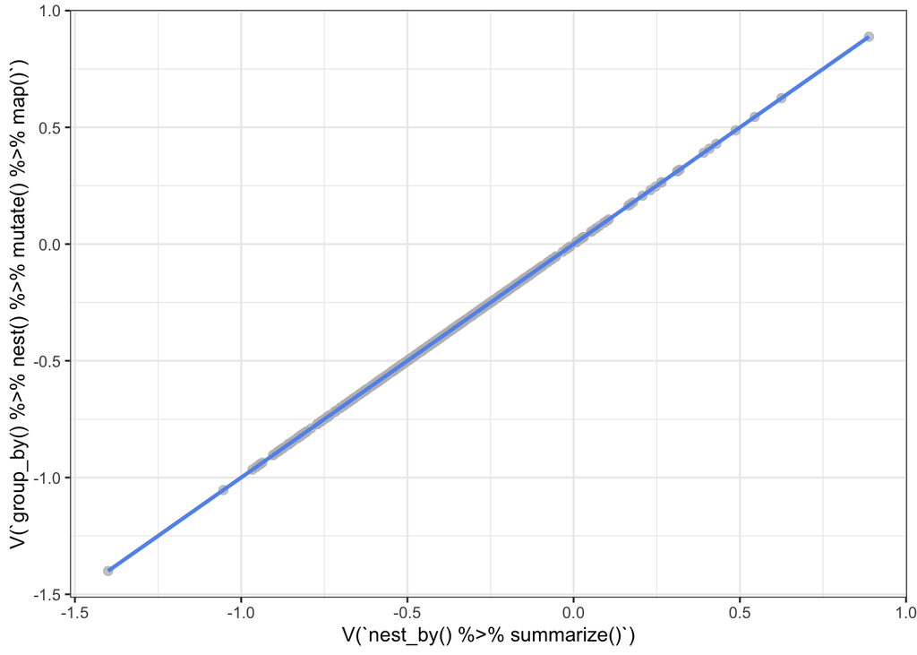

```r
d_nested1 %>%
  left_join(d_nested2, by = c('district', 'academic_year')) %>%
  ggplot(aes(x = v, # first method
             y = average_v)) + # second method
  geom_point(
    size = 2,
    color = 'gray',
    alpha = 0.8
  ) +
  geom_smooth(
    method = 'lm',
    se = F,
    color = 'cornflowerblue'
  ) +
  theme_bw() +
  labs(x = 'V(`nest_by() %>% summarize()`)',
       y = 'V(`group_by() %>% nest() %>% mutate() %>% map()`)')
```

```r
dists <-
  unique(d_nested1$district)[1:100]

dat <-
  d_nested1 %>%
  filter(district %in% dists) %>%
  left_join(schools_per_district, by = 'district') %>%
  select(-data, -auc)
```

### Method 1: nest()

```r
p <-
  dat %>%
  group_by(district, n_school) %>%
  nest() %>%
  mutate(
    plot = pmap(list(data, district, n_school), ~{
      ggplot(
        data = ..1,
        aes(
          x = academic_year,
          y = v,
          ymin = v - 1.96*v_se,
          ymax = v + 1.96*v_se,
          group = ..2
          )
        ) +
        geom_errorbar(width = 0.25) +
        geom_line() +
        geom_point(
          aes(
            color = ifelse(v < 0, '#D35CFF', '#5CA3FF')
            ),
          size = 2
          ) +
        geom_hline(
          yintercept = 0,
          color = '#DA5959'
          ) +
        scale_color_identity() +
        theme_minimal() +
        labs(
          x = 'School year',
          y = 'Average achievement difference (SD units)',
          caption = glue('Note: District included {..3} schools.'),
          title = glue('Achievement Gap Estimates: {..2} School District'),
          subtitle =
           "Negative values indicate <span style = 'color:#5CA3FF;'>White</span> students have higher average achievement <br> Positive values indicate <span style='color:#D35CFF;'>Hispanic/Latino</span> students have higher average achievement") +
        theme(
          plot.title.position = 'plot',
          plot.subtitle = element_markdown(),
          plot.title = element_markdown('bold')
          )
      }
)
)
```

### Method 2 nest_by()

```r
p2 <-
  dat %>%
  ungroup() %>%
  mutate(
    caption = glue('Note: District included {n_school} schools.'),
    title = glue('Achievement Gap Estimates: {district} School District'),
  ) %>%
  nest_by(district, caption, title) %>%
  mutate(
    plot = list(
      ggplot(
        data = data,
        aes(
          x = academic_year,
          y = v,
          ymin = v - 1.96*v_se,
          ymax = v + 1.96*v_se
          )
        ) +
        geom_errorbar(width = 0.25) +
        geom_line(group = district) +
        geom_point(
          aes(
            color = ifelse(v < 0, '#D35CFF', '#5CA3FF')
            ),
          size = 2
          ) +
        geom_hline(
          yintercept = 0,
          color = '#DA5959'
          ) +
        scale_color_identity() +
        theme_minimal() +
        labs(
          x = 'School year',
          y = 'Average achievement difference (SD units)',
          title = title,
          caption = caption,
          subtitle =
          "Negative values indicate <span style = 'color:#5CA3FF;'>White</span> students have higher average achievement <br> Positive values indicate <span style='color:#D35CFF;'>Hispanic/Latino</span> students have higher average achievement"
          ) +
        theme(
          plot.title.position = 'plot',
          plot.subtitle = element_markdown(),
          plot.title = element_markdown('bold')
          )
      )
    )
```

## Extra Credit

For up to one point extra credit, create a third set that “staples together” each of the preceding pairs of plots (i.e., to confirm that the plots were produced identically by both methods).

```r
## this works when we don't knit
## get an error I can't diagnose when we do
stapled_plots <-
  list(
    plots =
      map2(
        .x = p$plot,
        .y = p2$plot,
        ~grid.arrange(
          .x +
            labs(x = '', y = '', caption = ''),
          .y +
            labs(title = '', y = '', subtitle = '')
          ) %>%
          as_ggplot()
        )
    )
```

```r
stapled_plots$plots[1:3]
```

[output not shown]

## 4. Save the plots into a “plots” directory. Make sure the file names are meaningful.

```r
files <- str_replace_all(tolower(p$district), " ", "-")
paths <- here::here("Plots", glue("{files}.png"))
```

### Save plots to folder

```r
p %>%
  ungroup() %>%
  mutate(path = paths) %>%
  rowwise() %>%
  summarize(
    list(
      ggsave(
      path,
      plot,
      width = 9.5,
      height = 6.5,
      dpi = 500
    ))
    )
```